# Equity Matrix (EQM) algorithm

Bruno A Lima

2023-05-12

## Objectivo

Definir uma matriz de equidade que seja aplicável à seleção do par dador receptor em transplantação renal.

## Métodos

Para esta análise foram gerados dados sintéticos para um lista de espera simulada de 2000 candidatos a transplante com a respectiva informação clinica, imunológica e demográfica. Neste exercício, não foram gerados candidatos classificados como clinicamente urgentes.

Também foram gerados dados demográficos e imunológicos para um conjunto de 280 dadores de rim.

Os conjuntos de dados foram gerados com o *package* {simK}[^1]:

```
cndts <- simK::candidates_df(n = 2000,
                        replace = TRUE,
                        origin = 'PT',
                        probs.abo = c(0.44, 0.022, 0.042, 0.496),
                        probs.cpra = c(0.7, 0.1, 0.1, 0.1),
                        lower=18, upper=75,
                        mean.age = 45, sd.age = 15,
                        prob.dm = 0.12,
                        prob.urgent = 0,
                        uk = FALSE,
                        seed.number = 3) |>
      dplyr::mutate(dialysis = purrr::map2_dbl(.x = bg,
                                               .y = hiper,
                                               ~simK::dial(hiper = .y, bg = .x,
                                                           mean.dial1 = 25,
                                                           mean.dial2 = 60,
                                                           mean.dial3 = 75,
                                                           sd.dial = 20,
                                                           seed.number = NA)))|>
      dplyr::select(ID, bg, A1, A2, B1, B2, DR1, DR2, age, dialysis, cPRA, urgent)

antbs <- simK::Abs_df(candidates = cds,
                    origin = 'PT',
                    seed.number = 3)

dnrs <- simK::donors_df(n = 280,
                      replace = TRUE,
                      origin = 'PT',
                      probs = c(0.4658, 0.0343, 0.077, 0.4229),
                      lower=18, upper=75,
                      mean.age = 60, sd.age = 12,
                      uk = FALSE,
                      seed.number = 3)
```

### Descrição

Foram usados os algoritmos de alocação `lima()`, `et()` e `eqm()` disponíveis através do *package* {histoc}[^2].

Resumidamente, no modelo **Lima** os candidatos a transplante são classificados em cores de prioridade tendo em conta o respectivo tempo de diálise e o valor de cPRA: laranja para os doentes com cPRA > 85% ou tempo de diálise > 3º quartil; amarelo para os doentes com cPRa > 50% ou tempo de diálise > mediana; e verdes todos os restantes. Os candidatos são ainda inicialmente distribuidos tendo em conta o *Senior Program* (SP), ou seja, dadores >= 65 anos são alocados prioritáriamente a doentes >= 65 anos e dadores < 65 anos são alocados prioritáriamente a doentes < 65 (*Senior Program*).

O modelo do EuroTransplant **ET** aplica inicialmente o SP e o programa *Acceptable Missmatch* (AM) em que é dada prioridade aos candidatos hipersensibilizados. Na seleção do ET são priorizados também os pares dador-receptor com mmHLA 000, depois a ordenação dos candidatos segue um sistema de pontuação para a alocação dos órgãos.

Nos modelos de **matriz de equidade** são considerados como critérios de utilidade os mmHLA e o matching de longevidade. Para os critérios de justiça são considerados a mediana e o 3º quartil do tempo de diálise bem como os respectivos valores de cPRA, tal como descrito no separador ‘EQM’.

Para a construção das matrizes de equidade testadas, foi assumido um valor máximo de 100 e foram considerados os parâmetros:

- eqm0101: `uj_matx(max.val = 100, ratio.util = 0.1, ratio.just = 0.1)`
- eqm0102: `uj_matx(max.val = 100, ratio.util = 0.1, ratio.just = 0.2)`
- eqm0103: `uj_matx(max.val = 100, ratio.util = 0.1, ratio.just = 0.3)`
- eqm0104: `uj_matx(max.val = 100, ratio.util = 0.1, ratio.just = 0.4)`
- eqm0105: `uj_matx(max.val = 100, ratio.util = 0.1, ratio.just = 0.5)`
- eqm0201: `uj_matx(max.val = 100, ratio.util = 0.2, ratio.just = 0.1)`
- eqm0301: `uj_matx(max.val = 100, ratio.util = 0.3, ratio.just = 0.1)`
- eqm0401: `uj_matx(max.val = 100, ratio.util = 0.4, ratio.just = 0.1)`
- eqm0501: `uj_matx(max.val = 100, ratio.util = 0.5, ratio.just = 0.1)`

Foram considerados também modelos obtidos através destas matrizes mas aplicando inicialmente os critérios de priorização do ET, isto é, programas SP, AM e mmHLA 000 (`eqm(SP = TRUE, AM = TRUE, mm000 = TRUE)`):

- eqm_et_0101
- eqm_et_0102
- eqm_et_0103
- eqm_et_0104
- eqm_et_0105
- eqm_et_0201
- eqm_et_0301
- eqm_et_0401
- eqm_et_0501

Nesta análise e para todos os modelos foi considerado como 3º quartil do tempo de diálise 80 meses e como mediana 60 meses.

A alocação dos 280 dadores é feita selecionando os dois melhores candidatos para cada dador sem repetir os candidatos. Isto é, em cada iteração, para o primeiro dador são atribuidos os dois melhores candidatos (garantindo sempre a compatibilidade ABO e um XM virtual negativo), ao segundo dador são atribuidos os 2 melhores candidatos sobrantes (sem os atribuidos a dadores anteriores) e assim sucessivamente até serem atribuidos um máximo de 560 candidatos (2 x 280). Para garantir que a ordenação dos dadores não influencia os resultados, foram feitas até 1000 iterações em que para cada uma das iterações a ordem dos dadores para os quais são atribuidos os candidatos é alterada aleatoriamente.

Assim, para cada iteração é possível calcular valores médios das características dos candidatos seleccionados pelos modelos e construir as distribuições desses valores médios.

### EQM

#### Utility *vs* Justice

Duma forma geral, os princípios éticos que guiam a alocação de rins em transplantação são a utilidade e justiça. Se por um lado se pretende garantir um acesso justo e igual para todos os candidatos a transplante, por outro, deve-se promover uma alocação eficiente, ou seja, assegurar a utilidade do transplante. Assim, distinguimos como critérios:

- de utilidade:
  - *matching* de longevidade;
  - *matching* HLA;
- de justiça:
  - tempo de espera em diálise;
  - sensibilização HLA;
  - prévio dador vivo;
  - minorias étnicas;
  - prioridade pediátrica;
  - urgência médica.

#### EQM

De forma a equilibrar critérios de utilidade com critérios de justiça, a construção da matriz de equidade é feita através da função `histco::uj_matx()` considerando dois parâmetros:

- `ratio.util` - *A numerical value between 0 and 0.5 corresponding to the decreasing rate for the utility criterion (by row);*
- `ratio.just` - *A numerical value between 0 and 0.5 corresponding to the decreasing rate for the justice criterion (by column).*

Assim, a partir de um valor máximo inicial (geralmente 100), os valores por linha são obtidos subtraindo consecutivamente o peso dado à utilidade (Max * `ratio.util`), enquanto que aos valores por coluna é subtratido o peso dos critérios de justiça (MAX * `ratio.just`).

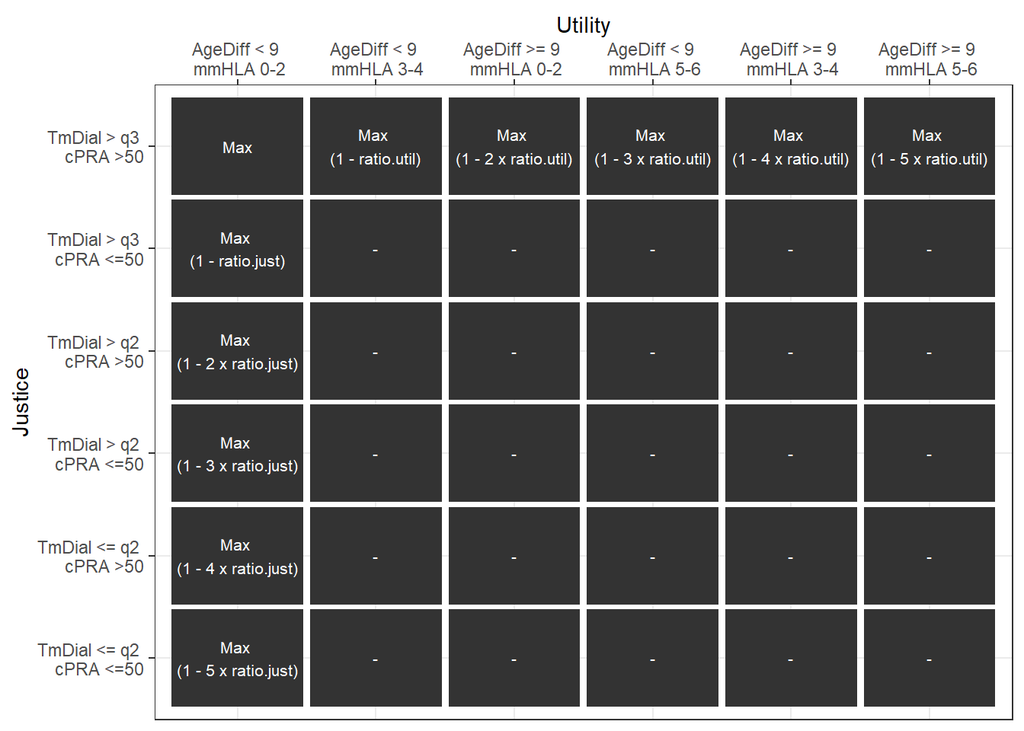

Como critérios de utilidade são considerados os mismatchs HLA (mmHLA) entre dador e receptor bem com um matching de longevidade obtido a partir da diferença absoluta entre as idades de dador e receptor (AgeDiff = |idade dador - idade receptor|). Com estes valores é obtida uma escala com 6 opções.

Como critérios de justiça são considerados o tempo em diálise (TmDial) dos candidatos a tranplante e os seus repectivos valores de cPRA. O TmDial é dividido de acordo com a mediana (q2) e 3º quartil (q3) dos tempos de diálise de todos os candidatos a transplante em análise, obtendo-se três grupos: TmDial > q3; q2 < TmDial <= q3; TmDial <= q2. Os valores de cPRA são dicotomizados no valor 50 (isto é, cPRA > 50 vs cPRA <= 50). Da combinação destes dois grupos é obtida uma uma escala com 6 opções.  
Assim, temos uma matriz de equidade final com 36 (6x6) valores.

Por exemplo, para um `ratio.util = 0.1` e `ratio.just = 0.1`, obtemos a matriz de equidade:

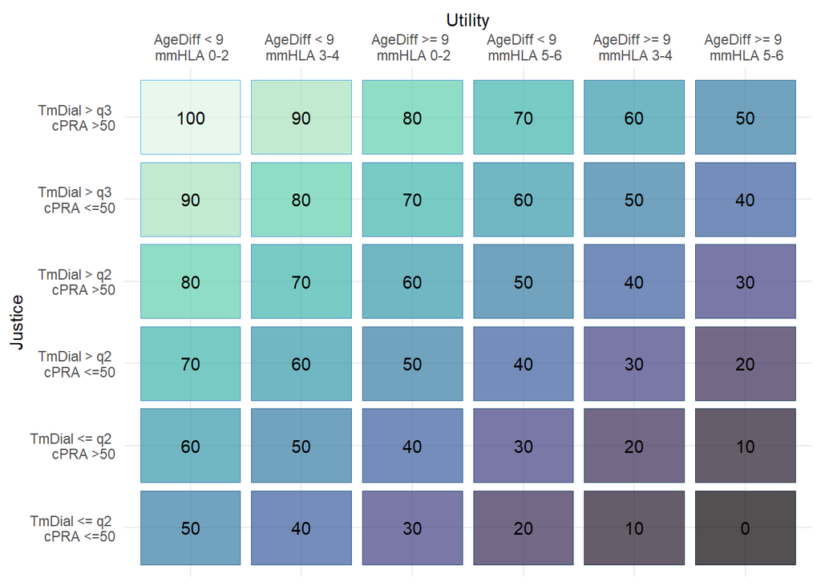

para um `ratio.util = 0.4` e `ratio.just = 0.1`, temos:

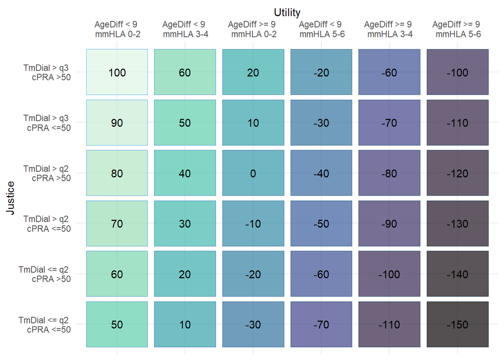

para um `ratio.util = 0.1` e `ratio.just = 0.4`, temos:

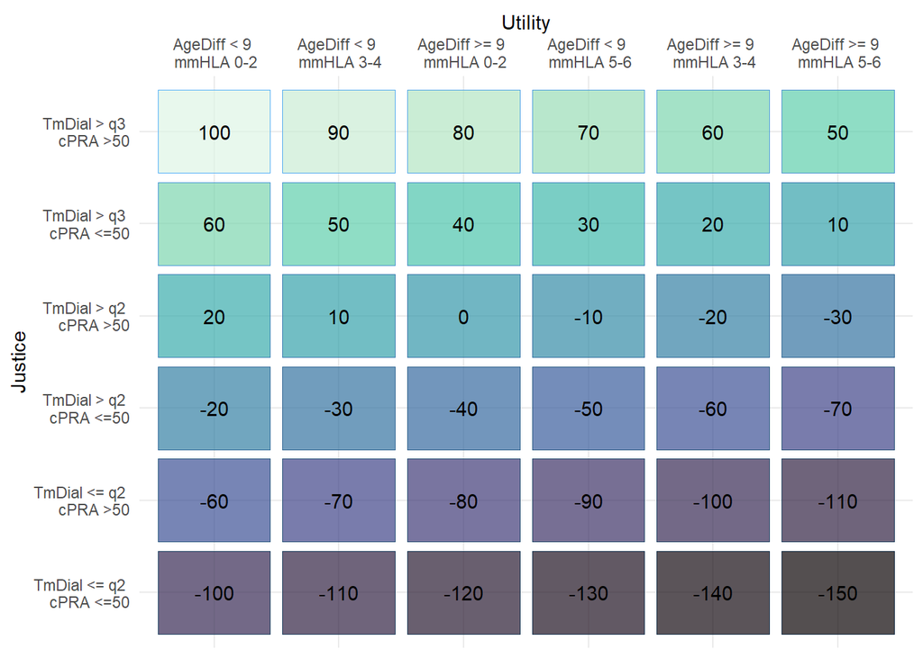

## Resultados

A comparação dos valores médios das caracteristicas dos receptores obtidos para cada iteração e para cada modelo de alocação é feito através da representação gráfica das suas distribuições.

### Idade

As matrizes que dão maior peso à utilidade (eqm0201, eqm0301, eqm0401 e eqm0501) são as que selecionam candidatos mais idosos, ou melhor, candidatos com idades mais próximas aos dadores. Neste exercício as idades dos dadores foram obtidas a partir duma distribuição $\sim N(60,12)$ pelo que é o modelo ‘eqm0501’ que seleciona candidatos com as idades mais próximas às dos dadores. No caso dos modelos ‘Lima’ e ‘ET’ como a idade de candidatos e dadores apenas é considerada para aplicação do *Senior program*, os receptores selecionados não são tão influenciados pelas idades dos dadores.

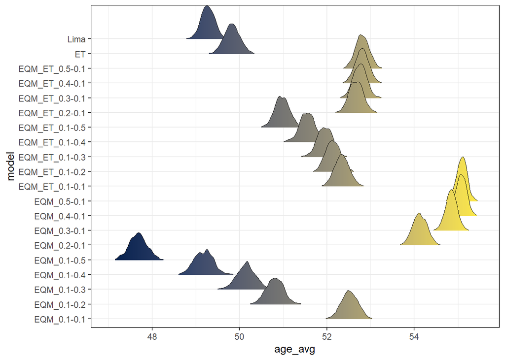

### Diferença de idades

(|idade dador - idade receptor|)

Tal como referido em cima, as matrizes que dão maior peso à utilidade selecionam receptores com idades mais próximas aos dadores, ou seja, com uma diferença de idades entre dador e receptor menor.

No caso das matrizes que aplicam as prioridades ET (eqm_et_), mesmo aqs que dão maior peso à utilidade (eqm_et_0501 - eqm_et_0201) as diferenças de idades são maiores mesmo que a verificada para eqm0101 dada a influencia do SP.

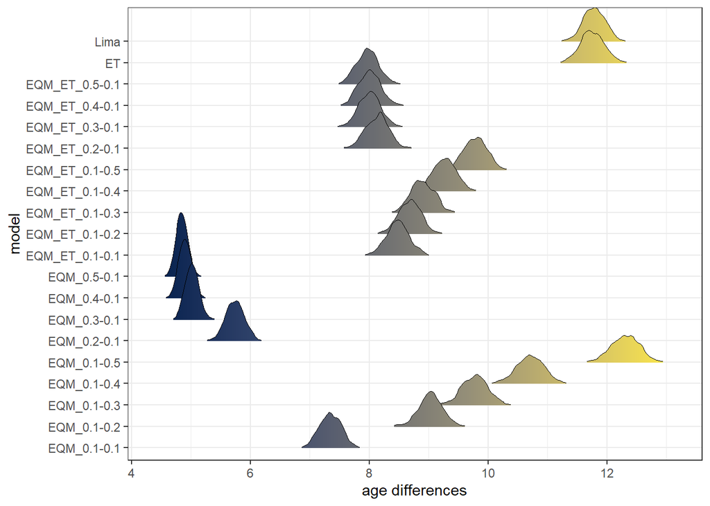

### mmHLA

Para o valor médio do número de mmHLA entre dador e receptor, são as matrizes que dão maior peso à utilidade as que selecionam pares com o menor número de mmHLA (como seria de esperar). Mesmo a matriz mais neutra (eqm0101) seleciona receptores com menos mmHLA que os modelos ‘Lima’, ‘ET’ e os que resultam das ‘eqm_et_’. Ou seja as priorizações do SP e AM condicionam os valores globais de mmHLA.

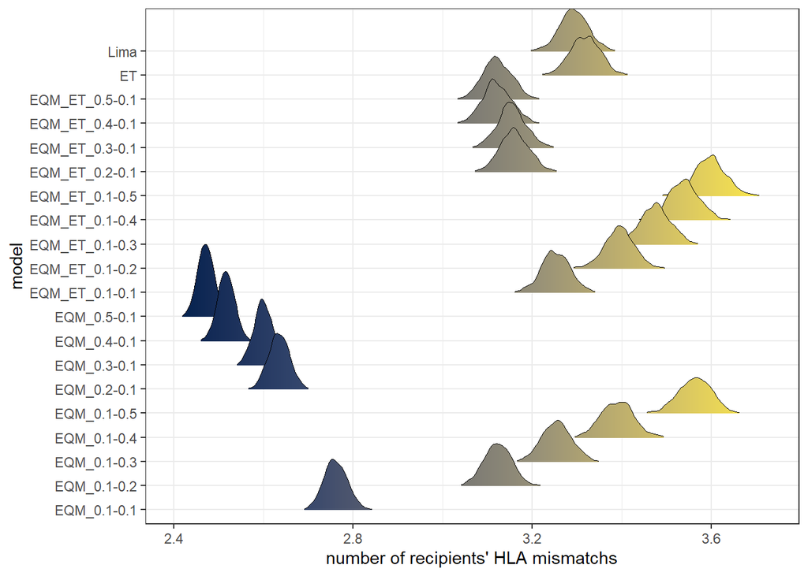

### mmHLA 000 (contagem)

Embora as matrizes que dão mais peso á utilidade selecionem mais receptores com zero mmHLA, este número não difere muito do obtido com o modelo ‘Lima’, uma vez que o número de mmHLA total apenas é usado na ordenação final em ambos os modelos. São os modelos ‘ET’ e ‘eqm_et_’ que selecionam um maior número de pares com 0 mmHLA uma vez que este é um critério de seleção dos pares.

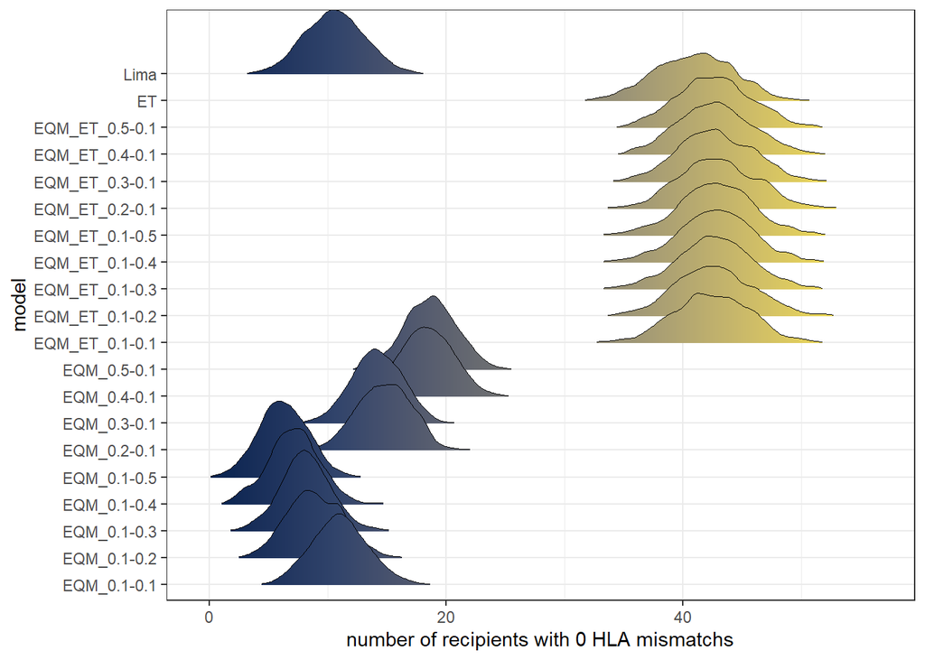

### mmHLA 0-2 (contagem)

Já o número de receptores com até 2 mmHLA é bastante superior na selecção das matrizes que dão maior peso à utilidade e na matriz neutra (eqm0101) em comparação com os receptores dos modelos ‘Lima’, ‘ET’ e todos os ‘eqm_et_’ mesmo quando é dado um maior peso à utilidade.

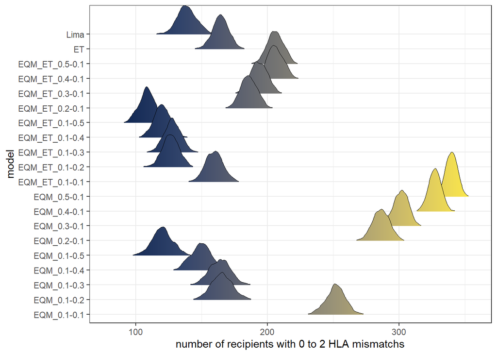

### mmHLA 6 (contagem)

No mesmo sentido, as matrizes (sem priorizações) que dão maior peso à utilidade selecionam menos receptores com 6 mmHLA.

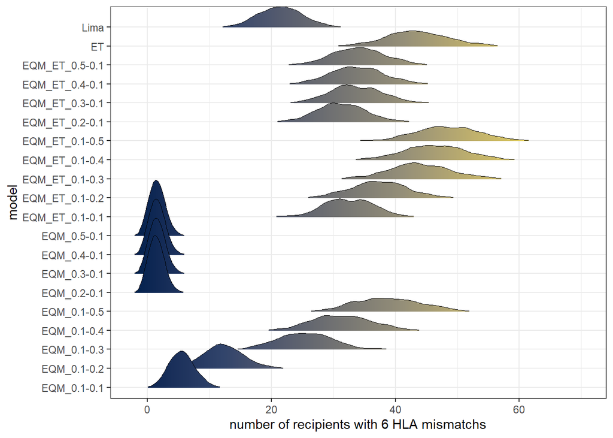

### tempo em diálise (meses)

Como expectável, as matrizes que dão maior peso à justiça (eqm0102, eqm0103, eqm0104, eqm0105) selecionam receptores com maiores tempos em diálise do que o modelo ‘Lima’. Ainda assim o modelo ‘Lima’ ainda consegue seleccionar receptores com maior tempo de diálise que o modelo neutro (eqm0101). O modelo ‘ET’ e os ‘eqm_et_’ selecionam candidados com menor tempo de diálise do que o modelo neutro ‘eqm0101’.

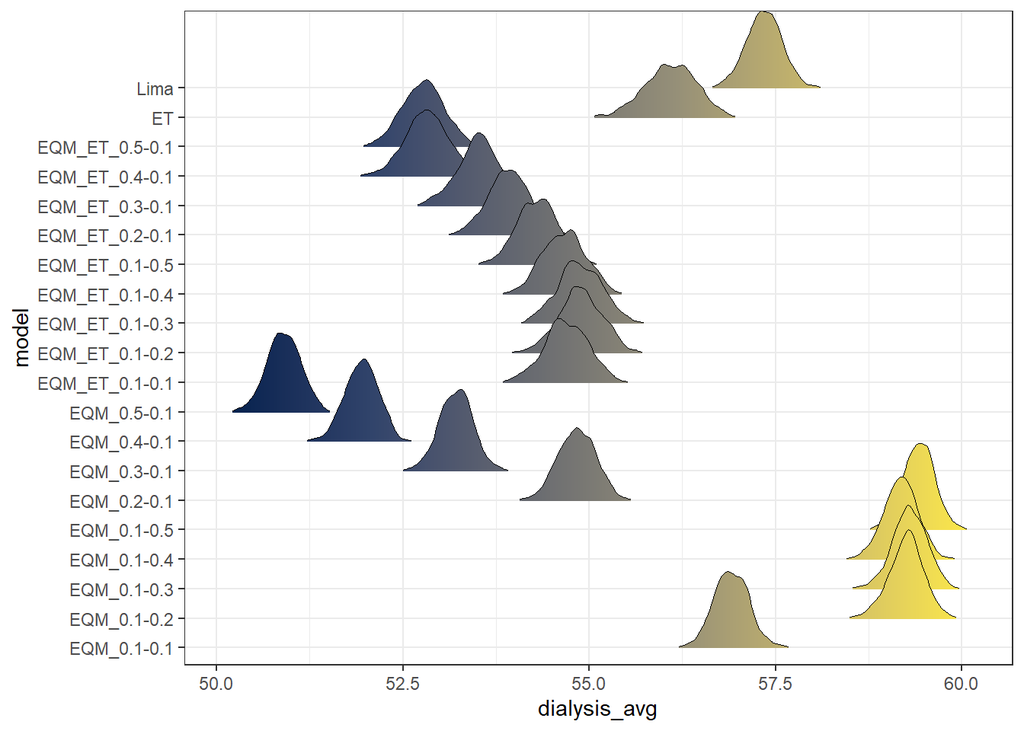

### cPRA (%)

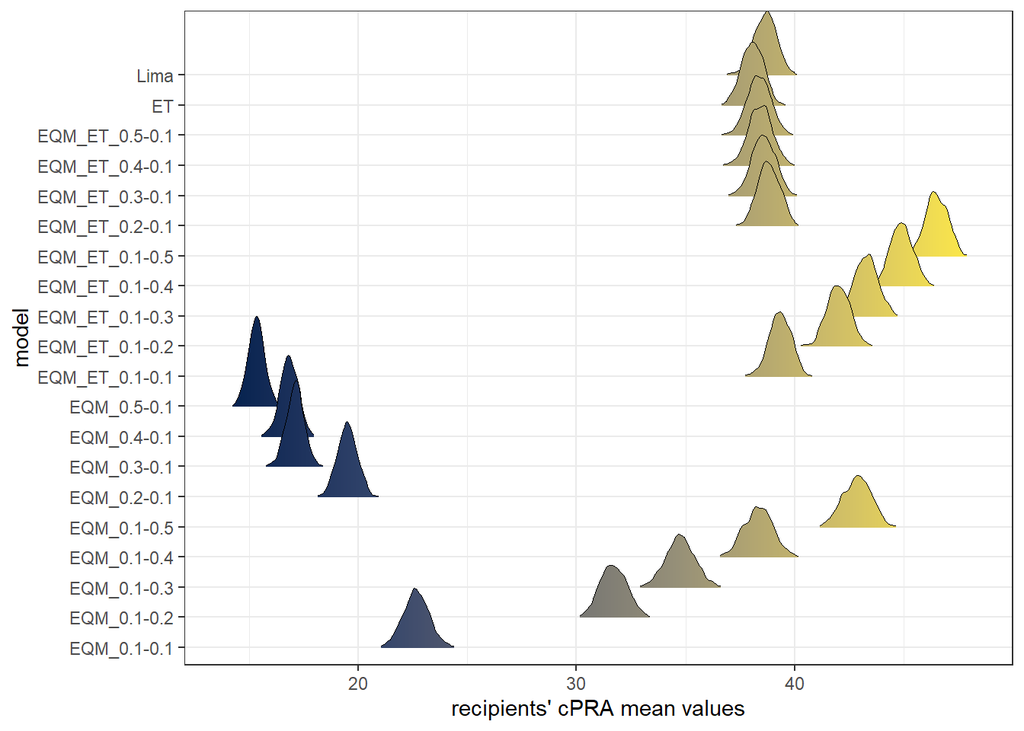

### Hipersensibilizados (contagem)

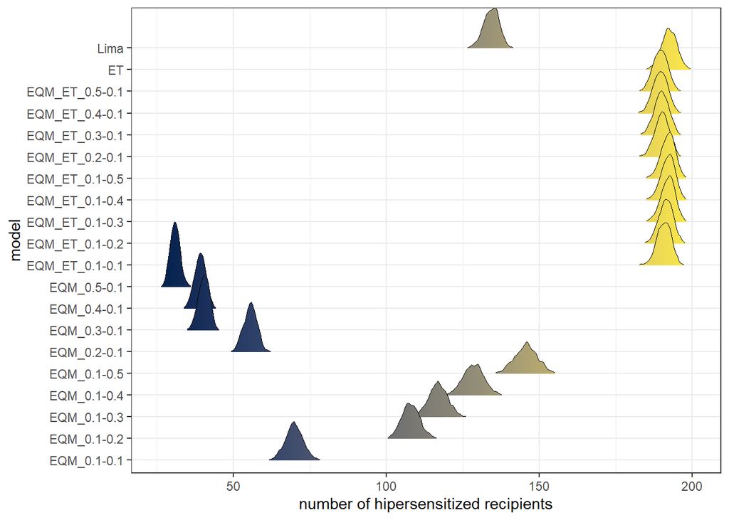

### Senior program (contagem)

Como um dos critérios dos modelo ‘Lima’, ‘ET’ e ‘eqm_et_’ aplicam as regrasas regras do *Senior program* (dadores maiores que 65 anos são alocados prioritariamente a candidatos 65+), o número de receptores 65+ com dadores 65+ é bastante superior nestes quando comparados aos resultados das matrizes sem priorização.

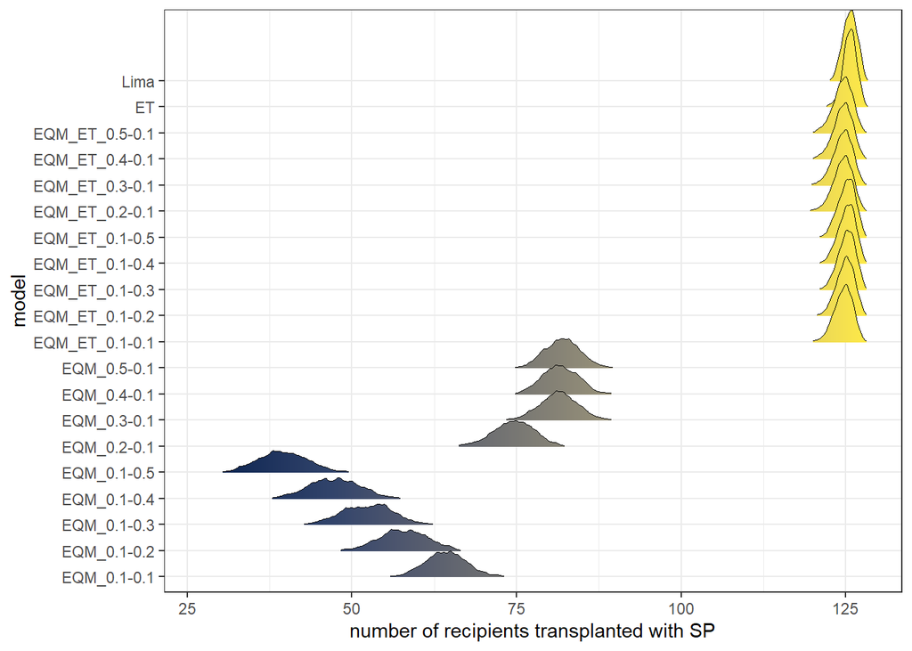

### Tx Score

(*Estimated 5-year event (mortality or graft failure) percentage*)

O cálculo do TxScore[^3] que devolve a percentagem (probabilidade) a 5 anos do evento (morte ou perda do enxerto) foi feito tendo em conta a idade do dador, a idade do receptor, o tempo de diálise e os mmHLA. Para todas as restantes variáveis usadas para o cálculo do TxScore, foram assumidos valores constantes.

Assim, os piores valores são obtidos para o modelo ‘Lima’, enquanto que os melhores resultados são dados pelas matrizes que dão maior peso á utilidade e ao modelo ET.

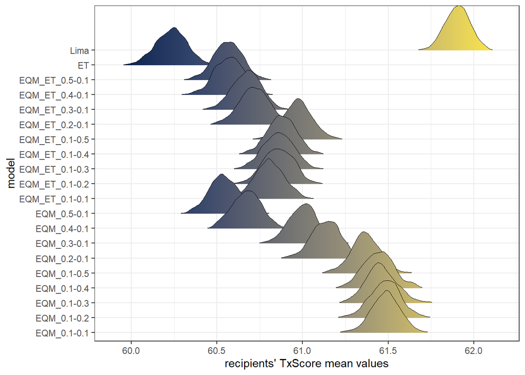

### Resumo

Se compararmos apenas o modelo ‘ET’ com o ‘eqm0101’ verificamos que o primeiro foi selecionado 5 vezes como sendo melhor que o segundo e outras 5 vezes como sendo pior.

Os resultados de cPRA e HI são redundantes uma vez que a variável HI é obtida a partir de cPRA > 85%.

Os (ligeiramente) melhores resultados do modelo ‘ET’ para a variável ‘TxScore’ podem dever-se ao facto deste modelo selecionar candidatos mais jovens e com menor tempo de diálise.

#### Rank dos modelos

| variable | Lima | ET | EQM_0.1-0.1 | EQM_ET_0.1-0.1 | best_model |
| --- | --- | --- | --- | --- | --- |
| ageDiff | 3 | 3 | 1 | 2 | EQM_0.5-0.1 |
| mmHLA | 3 | 4 | 1 | 2 | EQM_0.5-0.1 |
| mmHLA000 | 3 | 1 | 3 | 1 | EQM_ET_ |
| mmHLA0-2 | 4 | 2 | 1 | 2 | EQM_0.5-0.1 |
| mmHLA6 | 2 | 4 | 1 | 3 | EQM_0.5-0.1 |
| tmDial | 1 | 3 | 2 | 4 | EQM_0.1-0.5 |
| cPRA | 1 | 2 | 4 | 2 | EQM_ET_0.1-0.5 |
| Hiper | 3 | 1 | 4 | 2 | ET |
| SP | 1 | 1 | 4 | 1 | ET |
| TxScore | 4 | 1 | 3 | 2 | ET |

O TxScore, ao dar a probabilidade dum evento (morte ou perda do rim) a 5 anos, mede a eficácia do transplante e não a sua eficiência. Neste exercício, os dadores têm uma média de idades de 60 anos, enquanto a média de idades dos candidtos é de 45. Assim, é expectável que através do modelo ‘ET’ órgãos de dadores mais idosos sejam alocados a candidatos mais jovens o que não acontece com o modelo ‘eqm0101’ que tem como um dos critérios a proximidade de idades entre dador e receptor.

O transplante de receptores mais jovens com rins dum dador mais idoso traduzir-se-á numa redução dos valores do TxScore quando comparado com o transplante deste dador com um receptor mais idoso, no entanto poderá implicar a necessidade dos primeiros receptores voltarem à lista de espera para um novo transplante o que poderia não acontecer no caso de ser seleccionado um receptor mais idoso.

#### Descriptiva

**Table. Summary statistics by model from 1,0000 iterations**

| **Variable** | **EQM_0.1-0.1**, N = 1,000<sup>1</sup> | **EQM_ET_0.1-0.1**, N = 1,000<sup>1</sup> | **ET**, N = 1,000<sup>1</sup> | **Lima**, N = 1,000<sup>1</sup> |
| --- | --- | --- | --- | --- |
| recipients' age | 52.52 (+/- 0.19) | 52.34 (+/- 0.17) | 49.83 (+/- 0.18) | 49.27 (+/- 0.15) |
| age differences \|donor-recipient\| | 7.35 (+/- 0.18) | 8.48 (+/- 0.19) | 11.75 (+/- 0.20) | 11.78 (+/- 0.19) |
| number of HLA mm | 2.76 (+/- 0.03) | 3.25 (+/- 0.03) | 3.32 (+/- 0.03) | 3.29 (+/- 0.03) |
| pairs' with 0 HLA mm | 11.04 (+/- 2.36) | 42.51 (+/- 3.24) | 40.97 (+/- 3.37) | 10.58 (+/- 2.52) |
| pairs' with 0 to 2 HLA mm | 251.80 (+/- 7.32) | 159.64 (+/- 6.50) | 164.49 (+/- 6.18) | 138.80 (+/- 7.32) |
| pairs' with 6 HLA mm | 5.54 (+/- 1.92) | 32.54 (+/- 4.01) | 43.57 (+/- 5.03) | 21.48 (+/- 3.61) |
| time on dialysis | 56.91 (+/- 0.23) | 54.69 (+/- 0.29) | 56.09 (+/- 0.34) | 57.35 (+/- 0.24) |
| cPRA | 22.66 (+/- 0.59) | 39.32 (+/- 0.50) | 38.06 (+/- 0.50) | 38.64 (+/- 0.52) |
| Hipersensitized recipients | 69.87 (+/- 2.94) | 190.75 (+/- 2.28) | 192.44 (+/- 2.49) | 134.29 (+/- 2.50) |
| transplants with Senior Program | 64.31 (+/- 3.14) | 124.61 (+/- 1.34) | 125.57 (+/- 0.91) | 125.60 (+/- 0.95) |
| TxScore (%) | 61.49 (+/- 0.08) | 60.81 (+/- 0.09) | 60.23 (+/- 0.09) | 61.90 (+/- 0.07) |

<sup>1</sup> Mean (+/- SD)

#### effect size

Cohen’s d effect size for the difference of means from ET vs Lima

| variables | lower | effect | upper |
| --- | --- | --- | --- |
| age_avg | -3.516 | -3.346 | -3.174 |
| mmHLA_avg | -0.859 | -0.765 | -0.671 |
| mmHLA0_n | -10.672 | -10.218 | -9.759 |
| mmHLA6_n | -5.289 | -5.052 | -4.812 |
| dialysis_avg | 4.032 | 4.239 | 4.443 |
| cPRA_avg | 1.034 | 1.135 | 1.236 |
| HI_n | -24.320 | -23.301 | -22.270 |
| SP_n | -0.049 | 0.039 | 0.126 |
| txs_avg | 19.632 | 20.542 | 21.442 |
| ageDiff_avg | 0.079 | 0.167 | 0.254 |
| mmHLA02_n | -3.981 | -3.794 | -3.605 |

p-values:

```
##      age_avg    mmHLA_avg     mmHLA0_n     mmHLA1_n     mmHLA2_n     mmHLA3_n
##   0.00000000   0.00000000   0.00000000   0.00000000   0.00000000   0.00000000
##     mmHLA4_n     mmHLA5_n     mmHLA6_n dialysis_avg     cPRA_avg         HI_n
##   0.00000000   0.00000000   0.00000000   0.00000000   0.00000000   0.00000000
##         SP_n      txs_avg  ageDiff_avg    mmHLA02_n
##   0.38616284   0.00000000   0.00020248   0.00000000
```

Cohen’s d effect size for the difference of means from ET vs EQM_0.1-0.1

| variables | lower | effect | upper |
| --- | --- | --- | --- |
| age_avg | 14.078 | 14.734 | 15.382 |
| mmHLA_avg | -19.578 | -18.756 | -17.924 |
| mmHLA0_n | -10.750 | -10.293 | -9.830 |
| mmHLA6_n | -10.445 | -10.000 | -9.550 |
| dialysis_avg | 2.627 | 2.778 | 2.927 |
| cPRA_avg | -29.584 | -28.345 | -27.092 |
| HI_n | -46.920 | -44.958 | -42.974 |
| SP_n | -27.663 | -26.504 | -25.332 |
| txs_avg | 13.887 | 14.533 | 15.173 |
| ageDiff_avg | -24.233 | -23.217 | -22.190 |
| mmHLA02_n | 12.320 | 12.895 | 13.464 |

p-values:

```
##      age_avg    mmHLA_avg     mmHLA0_n     mmHLA1_n     mmHLA2_n     mmHLA3_n
##            0            0            0            0            0            0
##     mmHLA4_n     mmHLA5_n     mmHLA6_n dialysis_avg     cPRA_avg         HI_n
##            0            0            0            0            0            0
##         SP_n      txs_avg  ageDiff_avg    mmHLA02_n
##            0            0            0            0
```

Cohen’s d effect size for the difference of means from ET vs EQM_ET_0.1-0.1

| variables | lower | effect | upper |
| --- | --- | --- | --- |
| age_avg | 14.028 | 14.682 | 15.328 |
| mmHLA_avg | -2.139 | -2.015 | -1.890 |
| mmHLA0_n | 0.376 | 0.466 | 0.556 |
| mmHLA6_n | -2.566 | -2.428 | -2.290 |
| dialysis_avg | -4.598 | -4.388 | -4.176 |
| cPRA_avg | 2.395 | 2.537 | 2.678 |
| HI_n | -0.799 | -0.707 | -0.613 |
| SP_n | -0.927 | -0.832 | -0.737 |
| txs_avg | 6.233 | 6.534 | 6.832 |
| ageDiff_avg | -17.597 | -16.857 | -16.108 |
| mmHLA02_n | -0.859 | -0.765 | -0.671 |

p-values:

```
##      age_avg    mmHLA_avg     mmHLA0_n     mmHLA1_n     mmHLA2_n     mmHLA3_n
## 0.0000000000 0.0000000000 0.0000000000 0.0000000000 0.0000000000 0.0004249444
##     mmHLA4_n     mmHLA5_n     mmHLA6_n dialysis_avg     cPRA_avg         HI_n
## 0.0000000000 0.0000000000 0.0000000000 0.0000000000 0.0000000000 0.0000000000
##         SP_n      txs_avg  ageDiff_avg    mmHLA02_n
## 0.0000000000 0.0000000000 0.0000000000 0.0000000000
```

[^1]: available from: https://github.com/txopen/simK
[^2]: available from: https://github.com/txopen/histoc
[^3]: available from: https://balima.shinyapps.io/scoreTx/